# Internet Usage Data and analysis for North and South American countries (2000-2023)

Fareeha Malik (100785443)

## Discussion

The reason I chose this dataset was because I found it was interesting to see the internet usage increase of countries throughout the years. Several countries at first glance had lower data usage in the earlier years and I wanted to see how it increased over the years. However, without an analysis of the information I could not understand what was happening.

As I went through the creation of the different graphs I starting figuring out what exactly I wanted from the data, how to manipulate it and how to visualize it to understand the data. I also decided to choose only countries in North and South America due to geographical closeness and to create a sub-group. This made the data less overwhelming and easy to make relations and associations.

There are also several 3rd world countries within South America so the comparison between South America and North America and seeing how internet usage changed throughout the years was interesting. Furthermore, North America has technological hubs and more technologically advanced, so many of the results made sense.

Unfortunately, several countries in both South America and North America had missing data throughout the years and especially for the year 2023. This was a challenge because I wanted to make relationships between the year 2000 and 2023 to show a dramatic change in internet usage. However, because so many countries were available it was possible to see this change still for some countries.

Please note packages were commented out after being downloaded for the relevant code chunks.

#### Reference:

##### Global Internet Usage by Country (2000-2023) (https://www.kaggle.com/datasets/meleknur/global-internet-usage-by-country-2000-2023?resource=download)

#### Code References:

##### [1] (https://stackoverflow.com/questions/53707963/r-networkd3-sankey-plot-colours-not-displaying)

##### [2] https://scales.r-lib.org/index.html

#### Research references:

##### [1] https://blogs.iadb.org/caribbean-dev-trends/en/how-barbados-is-bridging-its-digital-infrastructure-gap/

#### AI Prompts:

##### Used as google search to find a list of North and South American Countries

(This may have caused some missing South American Countries as the list may not have been accurate from AI, When I used the list to determine what information/countries to include in my filtering vectoring). Prompt: “List North and South American Countries”

##### Understanding what SanKey’s are and their use cases

Used AI as a google search to help What are SanKey’s and what are their use cases are Prompt: “What are Sankey’s and what are their use case”

##### Data Manipulation

Manipulated the data here for clean and easy to use information. I removed the Country Codes, reordered the countries with highest 2023 internet usage and even renamed the Countries in the vector to match how country names were stored in world map.

```r
#Requirment 1
#data manipulation

#installing and loading libraries
#install.packages("dplyr")
#install.packages("tidyr")
#install.packages("ggplot2")
#install.packages("readr")


library(dplyr)
library(tidyr)
library(ggplot2)
library(readr)

#loading dataset (csv)
data <- read_csv("internet_usage.csv")
#testing data is loaded correctly

#view first few rows of data
head(data)
```

| Country Name | Country Code | 2000 | 2001 | 2002 | 2003 | 2004 | 2005 | 2006 | 2007 | 2008 | 2009 | 2010 | 2011 | 2012 | 2013 | 2014 | 2015 | 2016 | 2017 | 2018 | 2019 | 2020 | 2021 | 2022 | 2023 |
| --- | --- | --- | --- | --- | --- | --- | --- | --- | --- | --- | --- | --- | --- | --- | --- | --- | --- | --- | --- | --- | --- | --- | --- | --- | --- |
| Afghanistan | AFG | .. | 0.00472257 | 0.0045614 | 0.0878913 | 0.105809 | 1.22415 | 2.10712 | 1.9 | 1.84 | 3.55 | 4 | 5 | 5.45455 | 5.9 | 7 | 8.26 | 11 | 13.5 | 16.8 | 17.6 | 18.4 | .. | .. | .. |
| Albania | ALB | 0.114097 | 0.325798 | 0.390081 | 0.9719 | 2.42039 | 6.04389 | 9.60999 | 15.0361 | 23.86 | 41.2 | 45 | 47 | 49.4 | 51.8 | 54.3 | 56.9 | 59.6 | 62.4 | 65.4 | 68.5504 | 72.2377 | 79.3237 | 82.6137 | 83.1356 |
| Algeria | DZA | 0.491706 | 0.646114 | 1.59164 | 2.19536 | 4.63448 | 5.84394 | 7.37598 | 9.45119 | 10.18 | 11.23 | 12.5 | 14.9 | 18.2 | 22.5 | 29.5 | 38.2 | 42.9455 | 47.6911 | 49.0385 | 58.9776 | 60.6534 | 66.2356 | 71.2432 | .. |
| American Samoa | ASM | .. | .. | .. | .. | .. | .. | .. | .. | .. | .. | .. | .. | .. | .. | .. | .. | .. | .. | .. | .. | .. | .. | .. | .. |
| Andorra | AND | 10.5388 | .. | 11.2605 | 13.5464 | 26.838 | 37.6058 | 48.9368 | 70.87 | 70.04 | 78.53 | 81 | 81 | 82.7 | 84.4 | 86.1 | 87.9 | 89.7 | 91.5675 | .. | 90.7187 | 93.2056 | 93.8975 | 94.4855 | .. |
| Angola | AGO | 0.105046 | 0.136014 | 0.270377 | 0.370682 | 0.464815 | 1.14337 | 1.5 | 1.7 | 1.9 | 2.3 | 2.8 | 4.7 | 7.7 | 13 | 21.3623 | 22 | 23.2 | 26 | 29 | 32.1294 | 36.6347 | 37.8067 | 39.2935 | .. |

```r
#getting summary of dataset
summary(data)
```

```
 Country Name       Country Code           2000               2001
 Length:217         Length:217         Length:217         Length:217
 Class :character   Class :character   Class :character   Class :character
 Mode  :character   Mode  :character   Mode  :character   Mode  :character
     2002               2003               2004               2005
 Length:217         Length:217         Length:217         Length:217
 Class :character   Class :character   Class :character   Class :character
 Mode  :character   Mode  :character   Mode  :character   Mode  :character
     2006               2007               2008               2009
 Length:217         Length:217         Length:217         Length:217
 Class :character   Class :character   Class :character   Class :character
 Mode  :character   Mode  :character   Mode  :character   Mode  :character
     2010               2011               2012               2013
 Length:217         Length:217         Length:217         Length:217
 Class :character   Class :character   Class :character   Class :character
 Mode  :character   Mode  :character   Mode  :character   Mode  :character
     2014               2015               2016               2017
 Length:217         Length:217         Length:217         Length:217
 Class :character   Class :character   Class :character   Class :character
 Mode  :character   Mode  :character   Mode  :character   Mode  :character
     2018               2019               2020               2021
 Length:217         Length:217         Length:217         Length:217
 Class :character   Class :character   Class :character   Class :character
 Mode  :character   Mode  :character   Mode  :character   Mode  :character
     2022               2023
 Length:217         Length:217
 Class :character   Class :character
 Mode  :character   Mode  :character
```

```r
#debugging checking the datset structure
#str(data)

#manipulating and cleaning data (making year columns numeric and handling missing values)
data_clean <- data %>%
  mutate(across(starts_with("20"),
                ~na_if(., ".."),
                .names = "{.col}_clean")) %>%
  mutate(across(starts_with("20"),
                ~as.numeric(.)))
#debugging checking for conversion
#summary(data_clean)
#str(data_clean)

#removing the original columns before cleaning
data_cleaned <- data_clean %>%
  select(-one_of(as.character(2000:2023)))

#check result
#checking for conversion
summary(data_cleaned)
```

```
 Country Name       Country Code         2000_clean        2001_clean
 Length:217         Length:217         Min.   : 0.0000   Min.   : 0.0000
 Class :character   Class :character   1st Qu.: 0.3802   1st Qu.: 0.4558
 Mode  :character   Mode  :character   Median : 2.3225   Median : 2.9872
                                       Mean   : 8.7323   Mean   :10.6539
                                       3rd Qu.: 9.5152   3rd Qu.:13.8869
                                       Max.   :52.0000   Max.   :64.0000
                                       NA's   :21        NA's   :18
   2002_clean       2003_clean       2004_clean       2005_clean
 Min.   : 0.000   Min.   : 0.000   Min.   : 0.000   Min.   : 0.000
 1st Qu.: 1.058   1st Qu.: 1.514   1st Qu.: 2.138   1st Qu.: 2.866
 Median : 4.768   Median : 6.608   Median : 8.425   Median :11.245
 Mean   :13.618   Mean   :16.108   Mean   :18.520   Mean   :20.799
 3rd Qu.:19.249   3rd Qu.:23.933   3rd Qu.:27.959   3rd Qu.:34.216
 Max.   :79.120   Max.   :83.140   Max.   :83.890   Max.   :87.000
 NA's   :15       NA's   :21       NA's   :18       NA's   :17
   2006_clean       2007_clean      2008_clean       2009_clean
 Min.   : 0.000   Min.   : 0.00   Min.   : 0.000   Min.   : 0.000
 1st Qu.: 3.734   1st Qu.: 4.08   1st Qu.: 5.307   1st Qu.: 6.605
 Median :14.182   Median :16.49   Median :21.760   Median :26.445
 Mean   :23.380   Mean   :25.60   Mean   :28.513   Mean   :31.238
 3rd Qu.:38.000   3rd Qu.:40.95   3rd Qu.:46.030   3rd Qu.:51.528
 Max.   :89.510   Max.   :90.60   Max.   :91.000   Max.   :93.000
 NA's   :18       NA's   :13      NA's   :15       NA's   :15
   2010_clean      2011_clean      2012_clean      2013_clean
 Min.   : 0.00   Min.   : 0.00   Min.   : 0.00   Min.   : 0.00
 1st Qu.: 8.00   1st Qu.: 9.95   1st Qu.:11.36   1st Qu.:13.90
 Median :30.65   Median :35.01   Median :37.55   Median :41.40
 Mean   :34.32   Mean   :37.05   Mean   :39.78   Mean   :42.14
 3rd Qu.:55.00   3rd Qu.:58.55   3rd Qu.:63.58   3rd Qu.:66.45
 Max.   :93.39   Max.   :94.82   Max.   :96.21   Max.   :96.55
 NA's   :16      NA's   :13      NA's   :15      NA's   :16
   2014_clean      2015_clean       2016_clean       2017_clean
 Min.   : 0.99   Min.   : 1.084   Min.   : 1.177   Min.   : 2.004
 1st Qu.:17.14   1st Qu.:21.605   1st Qu.:24.050   1st Qu.:27.811
 Median :46.20   Median :50.220   Median :54.000   Median :59.828
 Mean   :45.21   Mean   :48.035   Mean   :51.390   Mean   :54.665
 3rd Qu.:70.00   3rd Qu.:72.209   3rd Qu.:76.296   3rd Qu.:78.844
 Max.   :98.16   Max.   :98.324   Max.   :98.240   Max.   :99.547
 NA's   :16      NA's   :17       NA's   :14       NA's   :11
   2018_clean      2019_clean       2020_clean       2021_clean
 Min.   : 4.00   Min.   : 6.018   Min.   :  7.40   Min.   :  9.642
 1st Qu.:35.86   1st Qu.:42.306   1st Qu.: 41.77   1st Qu.: 49.959
 Median :63.15   Median :68.606   Median : 72.18   Median : 75.651
 Mean   :57.86   Mean   :61.250   Mean   : 64.49   Mean   : 67.881
 3rd Qu.:80.51   3rd Qu.:83.045   3rd Qu.: 85.48   3rd Qu.: 87.390
 Max.   :99.65   Max.   :99.701   Max.   :100.00   Max.   :100.000
 NA's   :41      NA's   :31       NA's   :25       NA's   :27
   2022_clean       2023_clean
 Min.   : 11.28   Min.   : 18.00
 1st Qu.: 56.86   1st Qu.: 85.07
 Median : 79.13   Median : 89.54
 Mean   : 71.29   Mean   : 87.67
 3rd Qu.: 89.69   3rd Qu.: 94.94
 Max.   :100.00   Max.   :100.00
 NA's   :34       NA's   :158
```

```r
str(data_cleaned) #checking cleaned data
```

```
tibble [217 × 26] (S3: tbl_df/tbl/data.frame)
 $ Country Name: chr [1:217] "Afghanistan" "Albania" "Algeria" "American Samoa" ...
 $ Country Code: chr [1:217] "AFG" "ALB" "DZA" "ASM" ...
 $ 2000_clean  : num [1:217] NA 0.114 0.492 NA 10.539 ...
 $ 2001_clean  : num [1:217] 0.00472 0.3258 0.64611 NA NA ...
 $ 2002_clean  : num [1:217] 0.00456 0.39008 1.59164 NA 11.2605 ...
 $ 2003_clean  : num [1:217] 0.0879 0.9719 2.1954 NA 13.5464 ...
 $ 2004_clean  : num [1:217] 0.106 2.42 4.634 NA 26.838 ...
 $ 2005_clean  : num [1:217] 1.22 6.04 5.84 NA 37.61 ...
 $ 2006_clean  : num [1:217] 2.11 9.61 7.38 NA 48.94 ...
 $ 2007_clean  : num [1:217] 1.9 15.04 9.45 NA 70.87 ...
 $ 2008_clean  : num [1:217] 1.84 23.86 10.18 NA 70.04 ...
 $ 2009_clean  : num [1:217] 3.55 41.2 11.23 NA 78.53 ...
 $ 2010_clean  : num [1:217] 4 45 12.5 NA 81 2.8 47 45 25 62 ...
 $ 2011_clean  : num [1:217] 5 47 14.9 NA 81 4.7 52 51 32 69 ...
 $ 2012_clean  : num [1:217] 5.45 49.4 18.2 NA 82.7 ...
 $ 2013_clean  : num [1:217] 5.9 51.8 22.5 NA 84.4 13 63.4 59.9 41.9 78.9 ...
 $ 2014_clean  : num [1:217] 7 54.3 29.5 NA 86.1 ...
 $ 2015_clean  : num [1:217] 8.26 56.9 38.2 NA 87.9 ...
 $ 2016_clean  : num [1:217] 11 59.6 42.9 NA 89.7 ...
 $ 2017_clean  : num [1:217] 13.5 62.4 47.7 NA 91.6 ...
 $ 2018_clean  : num [1:217] 16.8 65.4 49 NA NA ...
 $ 2019_clean  : num [1:217] 17.6 68.6 59 NA 90.7 ...
 $ 2020_clean  : num [1:217] 18.4 72.2 60.7 NA 93.2 ...
 $ 2021_clean  : num [1:217] NA 79.3 66.2 NA 93.9 ...
 $ 2022_clean  : num [1:217] NA 82.6 71.2 NA 94.5 ...
 $ 2023_clean  : num [1:217] NA 83.1 NA NA NA ...
```

```r
#creating vector for North and South American Countries
north_south_countries <- c(
  "American Samoa", "Bahamas", "Barbados", "Belize", "Canada", "Cayman Is.",
  "Costa Rica", "Cuba", "Dominican Rep.", "El Salvador", "Grenada", "Guatemala",
  "Haiti", "Honduras", "Jamaica", "Mexico", "Nicaragua", "Panama", "Puerto Rico",
  "Trinidad and Tobago", "United States of America", "U.S. Virgin Is.", "Argentina",
  "Bolivia", "Brazil", "Chile", "Colombia", "Ecuador", "Guyana", "Paraguay", "Peru",
  "Suriname", "Uruguay", "Venezuela"
)


#filtering to only keep north and south american countries
data_american <- data_cleaned %>%
  filter(`Country Name` %in% north_south_countries)



#summary(data_american)
head(data_american)
```

| Country Name | Country Code | 2000_clean | 2001_clean | 2002_clean | 2003_clean | 2004_clean | 2005_clean | 2006_clean | 2007_clean | 2008_clean | 2009_clean | 2010_clean | 2011_clean | 2012_clean | 2013_clean | 2014_clean | 2015_clean | 2016_clean | 2017_clean | 2018_clean | 2019_clean | 2020_clean | 2021_clean | 2022_clean | 2023_clean |
| --- | --- | --- | --- | --- | --- | --- | --- | --- | --- | --- | --- | --- | --- | --- | --- | --- | --- | --- | --- | --- | --- | --- | --- | --- | --- |
| American Samoa | ASM | NA | NA | NA | NA | NA | NA | NA | NA | NA | NA | NA | NA | NA | NA | NA | NA | NA | NA | NA | NA | NA | NA | NA | NA |
| Argentina | ARG | 7.03868 | 9.78081 | 10.88210 | 11.9137 | 16.03670 | 17.72060 | 20.92720 | 25.9466 | 28.1126 | 34.00 | 45.00 | 51.00 | 55.80 | 59.90 | 64.7000 | 68.0431 | 70.9690 | 74.2949 | 77.7000 | 79.9470 | 85.5144 | 87.1507 | 88.3754 | 89.2290 |
| Barbados | BRB | 3.97368 | 11.93650 | 27.83630 | 39.6896 | 49.80000 | 52.50000 | 55.30000 | 58.2000 | 61.4000 | 64.70 | 65.10 | 66.50 | 71.20 | 71.80 | 71.9000 | 72.0000 | 72.2000 | 72.3000 | 72.4000 | 72.6000 | 72.6766 | 74.8596 | 76.2053 | NA |
| Belize | BLZ | 5.96384 | NA | 5.68425 | NA | 9.80000 | 17.00000 | 24.00000 | 24.6000 | 26.3000 | 27.20 | 28.20 | 30.70 | 31.00 | 33.60 | 38.7000 | 41.5900 | 44.5757 | 47.0826 | 49.8000 | 53.3000 | 57.0987 | 65.0198 | 70.3540 | NA |
| Bolivia | BOL | 1.44276 | 2.12046 | 3.11719 | 3.5086 | 4.43992 | 5.22758 | 6.20067 | 10.4992 | 12.5000 | 16.80 | 22.40 | 30.00 | 35.34 | 36.99 | 34.6016 | 37.4868 | 39.6975 | 43.8323 | 44.2861 | 47.4748 | 59.9401 | 65.9774 | 73.2831 | NA |
| Brazil | BRA | 2.87069 | 4.52849 | 9.14943 | 13.2076 | 19.07370 | 21.02270 | 28.17840 | 30.8800 | 33.8300 | 39.22 | 40.65 | 45.69 | 48.56 | 51.04 | 54.5510 | 58.3280 | 60.8725 | 67.4713 | 70.4343 | 73.9124 | 81.3427 | 80.6899 | 80.5278 | 84.1506 |

```r
#arranging the rows so that country with highest data in 2023 is displayes first
data_sorted <- data_american %>%
  arrange(desc(`2023_clean`))

#using tidyr to combine columns
data_sorted_united <- data_sorted  %>%
  unite(`Country Information`, `Country Name`, `Country Code`, sep = " (", remove = TRUE, na.rm = FALSE) %>%
  mutate(`Country Information` = paste0(`Country Information`,")"))



#testing
#head(data_sorted)
#print(colnames(data_american))
#print(colnames(data_cleaned))
#head(data_sorted, 3)
head(data_sorted_united)
```

| Country Information | 2000_clean | 2001_clean | 2002_clean | 2003_clean | 2004_clean | 2005_clean | 2006_clean | 2007_clean | 2008_clean | 2009_clean | 2010_clean | 2011_clean | 2012_clean | 2013_clean | 2014_clean | 2015_clean | 2016_clean | 2017_clean | 2018_clean | 2019_clean | 2020_clean | 2021_clean | 2022_clean | 2023_clean |
| --- | --- | --- | --- | --- | --- | --- | --- | --- | --- | --- | --- | --- | --- | --- | --- | --- | --- | --- | --- | --- | --- | --- | --- | --- |
| Chile (CHL) | 16.600000 | 19.10000 | 22.10000 | 25.47380 | 28.17790 | 31.17530 | 34.49780 | 35.9000 | 37.3000 | 41.56 | 45.00 | 52.2496 | 55.05 | 58.00 | 61.1100 | 76.6296 | 83.5586 | 82.3275 | 84.9000 | 85.0176 | 87.4593 | 88.8045 | 90.6769 | 94.1192 |
| Argentina (ARG) | 7.038680 | 9.78081 | 10.88210 | 11.91370 | 16.03670 | 17.72060 | 20.92720 | 25.9466 | 28.1126 | 34.00 | 45.00 | 51.0000 | 55.80 | 59.90 | 64.7000 | 68.0431 | 70.9690 | 74.2949 | 77.7000 | 79.9470 | 85.5144 | 87.1507 | 88.3754 | 89.2290 |
| Costa Rica (CRI) | 5.800250 | 9.55948 | 19.89490 | 20.33360 | 20.79230 | 22.07000 | 25.10000 | 28.4000 | 32.2900 | 34.33 | 36.50 | 39.2122 | 47.50 | 45.96 | 53.0000 | 59.7630 | 65.8804 | 71.5817 | 73.4797 | 81.2026 | 80.5302 | 82.7490 | 82.5980 | 85.1270 |
| Brazil (BRA) | 2.870690 | 4.52849 | 9.14943 | 13.20760 | 19.07370 | 21.02270 | 28.17840 | 30.8800 | 33.8300 | 39.22 | 40.65 | 45.6900 | 48.56 | 51.04 | 54.5510 | 58.3280 | 60.8725 | 67.4713 | 70.4343 | 73.9124 | 81.3427 | 80.6899 | 80.5278 | 84.1506 |
| Mexico (MEX) | 5.081380 | 7.03802 | 11.90000 | 12.90000 | 14.10000 | 17.21000 | 19.52000 | 20.8100 | 21.7100 | 26.34 | 31.05 | 37.1763 | 39.75 | 43.46 | 44.3857 | 57.4310 | 59.5404 | 53.0318 | 56.6596 | 69.6321 | 71.4902 | 75.6265 | 78.6322 | 81.1832 |
| Paraguay (PRY) | 0.747631 | 1.09879 | 1.79497 | 2.11194 | 3.45244 | 7.90701 | 7.96207 | 11.2100 | 14.2700 | 18.90 | 19.80 | 24.7635 | 29.34 | 36.90 | 43.0074 | 49.7163 | 53.4041 | 61.0758 | 64.9935 | 68.5176 | 73.9575 | 77.0184 | 76.2592 | 78.0948 |

##### World Map Creation

```r
#install.packages("sf")
#install.packages("rnaturalearth")
#install.packages("rnaturalearthdata")
library(sf)
library(rnaturalearth)
library(rnaturalearthdata)

#decided to remove country codes

print(data_sorted_united)
```

| Country Information | 2000_clean | 2001_clean | 2002_clean | 2003_clean | 2004_clean | 2005_clean | 2006_clean | 2007_clean | 2008_clean | 2009_clean | 2010_clean | 2011_clean | 2012_clean | 2013_clean | 2014_clean | 2015_clean | 2016_clean | 2017_clean | 2018_clean | 2019_clean | 2020_clean | 2021_clean | 2022_clean | 2023_clean |
| --- | --- | --- | --- | --- | --- | --- | --- | --- | --- | --- | --- | --- | --- | --- | --- | --- | --- | --- | --- | --- | --- | --- | --- | --- |
| Chile (CHL) | 16.600000 | 19.100000 | 22.100000 | 25.47380 | 28.17790 | 31.17530 | 34.49780 | 35.9000 | 37.3000 | 41.56 | 45.00 | 52.2496 | 55.0500 | 58.0000 | 61.1100 | 76.6296 | 83.5586 | 82.3275 | 84.9000 | 85.0176 | 87.45930 | 88.80450 | 90.6769 | 94.1192 |
| Argentina (ARG) | 7.038680 | 9.780810 | 10.882100 | 11.91370 | 16.03670 | 17.72060 | 20.92720 | 25.9466 | 28.1126 | 34.00 | 45.00 | 51.0000 | 55.8000 | 59.9000 | 64.7000 | 68.0431 | 70.9690 | 74.2949 | 77.7000 | 79.9470 | 85.51440 | 87.15070 | 88.3754 | 89.2290 |
| Costa Rica (CRI) | 5.800250 | 9.559480 | 19.894900 | 20.33360 | 20.79230 | 22.07000 | 25.10000 | 28.4000 | 32.2900 | 34.33 | 36.50 | 39.2122 | 47.5000 | 45.9600 | 53.0000 | 59.7630 | 65.8804 | 71.5817 | 73.4797 | 81.2026 | 80.53020 | 82.74900 | 82.5980 | 85.1270 |
| Brazil (BRA) | 2.870690 | 4.528490 | 9.149430 | 13.20760 | 19.07370 | 21.02270 | 28.17840 | 30.8800 | 33.8300 | 39.22 | 40.65 | 45.6900 | 48.5600 | 51.0400 | 54.5510 | 58.3280 | 60.8725 | 67.4713 | 70.4343 | 73.9124 | 81.34270 | 80.68990 | 80.5278 | 84.1506 |
| Mexico (MEX) | 5.081380 | 7.038020 | 11.900000 | 12.90000 | 14.10000 | 17.21000 | 19.52000 | 20.8100 | 21.7100 | 26.34 | 31.05 | 37.1763 | 39.7500 | 43.4600 | 44.3857 | 57.4310 | 59.5404 | 53.0318 | 56.6596 | 69.6321 | 71.49020 | 75.62650 | 78.6322 | 81.1832 |
| Paraguay (PRY) | 0.747631 | 1.098790 | 1.794970 | 2.11194 | 3.45244 | 7.90701 | 7.96207 | 11.2100 | 14.2700 | 18.90 | 19.80 | 24.7635 | 29.3400 | 36.9000 | 43.0074 | 49.7163 | 53.4041 | 61.0758 | 64.9935 | 68.5176 | 73.95750 | 77.01840 | 76.2592 | 78.0948 |
| Ecuador (ECU) | 1.462190 | 2.670440 | 4.260800 | 4.46023 | 4.83444 | 5.99426 | 7.20000 | 10.8000 | 18.8000 | 24.60 | 29.03 | 31.3668 | 35.1351 | 40.2791 | 45.5904 | 48.9404 | 54.0629 | 55.8000 | 57.5000 | 59.2000 | 70.70000 | 70.20730 | 69.7181 | 72.6943 |
| American Samoa (ASM) | NA | NA | NA | NA | NA | NA | NA | NA | NA | NA | NA | NA | NA | NA | NA | NA | NA | NA | NA | NA | NA | NA | NA | NA |
| Barbados (BRB) | 3.973680 | 11.936500 | 27.836300 | 39.68960 | 49.80000 | 52.50000 | 55.30000 | 58.2000 | 61.4000 | 64.70 | 65.10 | 66.5000 | 71.2000 | 71.8000 | 71.9000 | 72.0000 | 72.2000 | 72.3000 | 72.4000 | 72.6000 | 72.67660 | 74.85960 | 76.2053 | NA |
| Belize (BLZ) | 5.963840 | NA | 5.684250 | NA | 9.80000 | 17.00000 | 24.00000 | 24.6000 | 26.3000 | 27.20 | 28.20 | 30.7000 | 31.0000 | 33.6000 | 38.7000 | 41.5900 | 44.5757 | 47.0826 | 49.8000 | 53.3000 | 57.09870 | 65.01980 | 70.3540 | NA |

[output cut: 20 more lines]

```r
data_sorted_united <- data_sorted_united %>%
  mutate(`Country Name` = gsub("\\s*\\(.*\\)","", `Country Information`))

#debugging trouble shooting
#print(unique(data_sorted_united$`Country Name`)) # Verify USA is renamed
#subset(data_map, name == "United States")
#print(unique(world_map$name))
#"United States of America" %in% world_map$name
#"United States of America" %in% world_map$name
#sum(is.na(data_sorted_united$"United States"))


#load world map data
world_map <- ne_countries(scale ="medium", returnclass = "sf")
unique(world_map$name)
```

```
  [1] "Zimbabwe"                  "Zambia"
  [3] "Yemen"                     "Vietnam"
  [5] "Venezuela"                 "Vatican"
  [7] "Vanuatu"                   "Uzbekistan"
  [9] "Uruguay"                   "Micronesia"
 [11] "Marshall Is."              "N. Mariana Is."
 [13] "U.S. Virgin Is."           "Guam"
 [15] "American Samoa"            "Puerto Rico"
 [17] "United States of America"  "S. Geo. and the Is."
 [19] "Br. Indian Ocean Ter."     "Saint Helena"
 [21] "Pitcairn Is."              "Anguilla"
 [23] "Falkland Is."              "Cayman Is."
 [25] "Bermuda"                   "British Virgin Is."
 [27] "Turks and Caicos Is."      "Montserrat"
 [29] "Jersey"                    "Guernsey"
```

[output cut: 106 more lines]

```r
#filtering for north and south america
world_map_filtered <- world_map  %>%
  filter(name %in% north_south_countries)

#print(north_south_countries)


#merging filtered dataset with the geographic data
data_map <- merge(world_map_filtered, data_sorted_united, by.x = "name", by.y= "Country Name", all.x = TRUE)



#debugging check for name difference between data_sorted_unite set and natural earth set
#setdiff(data_sorted_united$`Country Name`, world_map$name)
#print(unique(world_map$name)) #output the existing country names in the natural earth set

#debugging
#print(data_sorted_united)
print(data_sorted_united)
```

| Country Information | 2000_clean | 2001_clean | 2002_clean | 2003_clean | 2004_clean | 2005_clean | 2006_clean | 2007_clean | 2008_clean | 2009_clean | 2010_clean | 2011_clean | 2012_clean | 2013_clean | 2014_clean | 2015_clean | 2016_clean | 2017_clean | 2018_clean | 2019_clean | 2020_clean | 2021_clean | 2022_clean | 2023_clean | Country Name |
| --- | --- | --- | --- | --- | --- | --- | --- | --- | --- | --- | --- | --- | --- | --- | --- | --- | --- | --- | --- | --- | --- | --- | --- | --- | --- |
| Chile (CHL) | 16.600000 | 19.100000 | 22.100000 | 25.47380 | 28.17790 | 31.17530 | 34.49780 | 35.9000 | 37.3000 | 41.56 | 45.00 | 52.2496 | 55.0500 | 58.0000 | 61.1100 | 76.6296 | 83.5586 | 82.3275 | 84.9000 | 85.0176 | 87.45930 | 88.80450 | 90.6769 | 94.1192 | Chile |
| Argentina (ARG) | 7.038680 | 9.780810 | 10.882100 | 11.91370 | 16.03670 | 17.72060 | 20.92720 | 25.9466 | 28.1126 | 34.00 | 45.00 | 51.0000 | 55.8000 | 59.9000 | 64.7000 | 68.0431 | 70.9690 | 74.2949 | 77.7000 | 79.9470 | 85.51440 | 87.15070 | 88.3754 | 89.2290 | Argentina |
| Costa Rica (CRI) | 5.800250 | 9.559480 | 19.894900 | 20.33360 | 20.79230 | 22.07000 | 25.10000 | 28.4000 | 32.2900 | 34.33 | 36.50 | 39.2122 | 47.5000 | 45.9600 | 53.0000 | 59.7630 | 65.8804 | 71.5817 | 73.4797 | 81.2026 | 80.53020 | 82.74900 | 82.5980 | 85.1270 | Costa Rica |
| Brazil (BRA) | 2.870690 | 4.528490 | 9.149430 | 13.20760 | 19.07370 | 21.02270 | 28.17840 | 30.8800 | 33.8300 | 39.22 | 40.65 | 45.6900 | 48.5600 | 51.0400 | 54.5510 | 58.3280 | 60.8725 | 67.4713 | 70.4343 | 73.9124 | 81.34270 | 80.68990 | 80.5278 | 84.1506 | Brazil |
| Mexico (MEX) | 5.081380 | 7.038020 | 11.900000 | 12.90000 | 14.10000 | 17.21000 | 19.52000 | 20.8100 | 21.7100 | 26.34 | 31.05 | 37.1763 | 39.7500 | 43.4600 | 44.3857 | 57.4310 | 59.5404 | 53.0318 | 56.6596 | 69.6321 | 71.49020 | 75.62650 | 78.6322 | 81.1832 | Mexico |
| Paraguay (PRY) | 0.747631 | 1.098790 | 1.794970 | 2.11194 | 3.45244 | 7.90701 | 7.96207 | 11.2100 | 14.2700 | 18.90 | 19.80 | 24.7635 | 29.3400 | 36.9000 | 43.0074 | 49.7163 | 53.4041 | 61.0758 | 64.9935 | 68.5176 | 73.95750 | 77.01840 | 76.2592 | 78.0948 | Paraguay |
| Ecuador (ECU) | 1.462190 | 2.670440 | 4.260800 | 4.46023 | 4.83444 | 5.99426 | 7.20000 | 10.8000 | 18.8000 | 24.60 | 29.03 | 31.3668 | 35.1351 | 40.2791 | 45.5904 | 48.9404 | 54.0629 | 55.8000 | 57.5000 | 59.2000 | 70.70000 | 70.20730 | 69.7181 | 72.6943 | Ecuador |
| American Samoa (ASM) | NA | NA | NA | NA | NA | NA | NA | NA | NA | NA | NA | NA | NA | NA | NA | NA | NA | NA | NA | NA | NA | NA | NA | NA | American Samoa |
| Barbados (BRB) | 3.973680 | 11.936500 | 27.836300 | 39.68960 | 49.80000 | 52.50000 | 55.30000 | 58.2000 | 61.4000 | 64.70 | 65.10 | 66.5000 | 71.2000 | 71.8000 | 71.9000 | 72.0000 | 72.2000 | 72.3000 | 72.4000 | 72.6000 | 72.67660 | 74.85960 | 76.2053 | NA | Barbados |
| Belize (BLZ) | 5.963840 | NA | 5.684250 | NA | 9.80000 | 17.00000 | 24.00000 | 24.6000 | 26.3000 | 27.20 | 28.20 | 30.7000 | 31.0000 | 33.6000 | 38.7000 | 41.5900 | 44.5757 | 47.0826 | 49.8000 | 53.3000 | 57.09870 | 65.01980 | 70.3540 | NA | Belize |

[output cut: 20 more lines]

```r
subset(data_sorted_united, `Country Name` == "United States of America")
```

| Country Information | 2000_clean | 2001_clean | 2002_clean | 2003_clean | 2004_clean | 2005_clean | 2006_clean | 2007_clean | 2008_clean | 2009_clean | 2010_clean | 2011_clean | 2012_clean | 2013_clean | 2014_clean | 2015_clean | 2016_clean | 2017_clean | 2018_clean | 2019_clean | 2020_clean | 2021_clean | 2022_clean | 2023_clean | Country Name |
| --- | --- | --- | --- | --- | --- | --- | --- | --- | --- | --- | --- | --- | --- | --- | --- | --- | --- | --- | --- | --- | --- | --- | --- | --- | --- |
| United States of America (USA) | 43.0792 | 49.0808 | 58.7854 | 61.6971 | 64.7583 | 67.9681 | 68.9312 | 75 | 74 | 71 | 71.69 | 69.7295 | 74.7 | 71.4 | 73 | 74.5542 | 85.5444 | 87.2749 | 88.4989 | 89.4303 | 96.5768 | 96.7792 | 97.1299 | NA | United States of America |

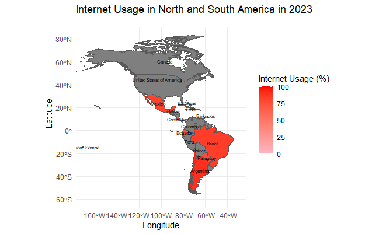

```r
# Check the 2000 value for USA
#usa_2000_value <- data_map[data_map$name == "United States of America", ]
#print(usa_2000_value)


#creating choropleth map
ggplot(data = data_map)+
  geom_sf(aes(fill = `2023_clean`)) +
  scale_fill_gradient(low = "lightpink", high="red", limits = c(0,100)) +
  theme_minimal()+
  labs(title = "Internet Usage in North and South America in 2023", fill = "Internet Usage (%)",
       x = "Longitude", #x axis label
       y = "Latitude" #y axis label
       )+
  geom_text( data = st_centroid(data_map),
    aes(x=st_coordinates(geometry)[, 1], y= st_coordinates(geometry)[,2],label = name),
    size=2, color="black", check_overlap = TRUE, hjust=0.5, vjust =0.5)+
coord_sf(xlim = c(-170, -30), ylim = c(-60, 90))
```

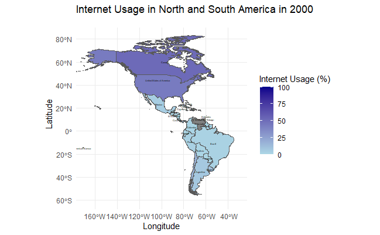

```r
#manually adding USA data
usa_internet_usage_2000 <- 43.0792

#update 2000 value of usa into data map
data_map$`2000_clean`[data_map$name == "United States of America"] <- usa_internet_usage_2000


#creating choropleth map
ggplot(data = data_map)+
  geom_sf(aes(fill = `2000_clean`)) +
  scale_fill_gradient(low = "lightblue", high="darkblue", limits = c(0,100)) +
  theme_minimal()+
  labs(title = "Internet Usage in North and South America in 2000", fill = "Internet Usage (%)",
       x = "Longitude", #x axis label
       y = "Latitude" #y axis label
       )+
  geom_text( data = st_centroid(data_map),
    aes(x=st_coordinates(geometry)[, 1], y= st_coordinates(geometry)[,2],label = name),
    size=1, color="black", check_overlap = TRUE, hjust=0.5, vjust =0.5)+
coord_sf(xlim = c(-170, -30), ylim = c(-60, 90))
```

```r
#TESTS
# Check if United States is in the merged data (kept having no coloring of map)
#subset(data_map, name == "United States of America")
setdiff(data_sorted_united$`Country Name`, world_map$name)
```

```
character(0)
```

```r
# Check if USA is in the dataset before merging
#subset(data_sorted_united, `Country Name` == "United States of America")
```

##### Sankey creation

Based on the assignment document I wanted to try a Sankey because I though it would show cool usage relationships from below to above 50% internet usage from 2000 to 2023. But the graph was not very interesting and it was hard to undertand. I tried to recode many times and also since I did not have a categorization I made one myself for below and above 50%. I later realised this was not very informative. I also did debuggin to find out 20+ countries had missing data so no proper relationships could be formed between source and target.

```r
#SANKEY graph
#install.packages("networkD3")
library(networkD3)
library(htmltools)

#categorizing countries in below and above 50% usage from 2000 to 2023

data_sorted_united <- data_sorted_united %>%
  mutate(
    usage_2000 = ifelse(`2000_clean`< 50 ,paste(`Country Name`,"Below 50% usage"), paste(`Country Name`, "Above 50% usage") ),
    usage_2023 = ifelse(`2023_clean` < 50 ,paste(`Country Name`,"Below 50% usage"), paste(`Country Name`, "Above 50% usage") )
  )


#transtion data creationg
transition_data <- data_sorted_united %>%
mutate (
  source = usage_2000,
  target = usage_2023
) %>%
  count(source, target, name="value")

#creating node list with country and usage categories
nodes <- data.frame(name=unique(c(
  transition_data$source,
  transition_data$target
  #data_sorted_united$`Country Name`
  )))

#creating links to match node
transition_data <- transition_data   %>%
mutate(
  #maping source and target to node indices
 source_id = match(source, nodes$name)-1,
 target_id = match(target, nodes$name)-1,
 value = value #every link is one country

)

#checking for NA values in source or target
sum(is.na(transition_data$source))
```

```
[1] 1
```

```r
sum(is.na(transition_data$target))
```

```
[1] 22
```

```r
#filtering for rows so no NAs in data
transition_data <- transition_data %>%
  filter(!is.na(source)&!is.na(target))

#create sankey graph
sankeyNetwork(Links = transition_data,
              Nodes= nodes,
              Source="source_id",
              Target ="target_id",
              Value ="value",
              NodeID = "name",
              fontSize = 15,
              nodeWidth = 30,
              width = 1200,
              height =800,
              nodePadding = 30,
              )
```

```
Links is a tbl_df. Converting to a plain data frame.
```

[interactive chart not shown]

```r
#troubleshooting issues
#issue was NodeId instead of NodeID
print(nodes)
```

| name |
| --- |
| Argentina Below 50% usage |
| Barbados Below 50% usage |
| Belize Below 50% usage |
| Bolivia Below 50% usage |
| Brazil Below 50% usage |
| Canada Above 50% usage |
| Chile Below 50% usage |
| Colombia Below 50% usage |
| Costa Rica Below 50% usage |
| Cuba Below 50% usage |

[output cut: 26 more lines]

```r
#print(data_sorted_united)
#sum(is.na(data_sorted_united$source))
#sum(is.na(data_sorted_united$target))
print(transition_data)
```

| source | target | value | source_id | target_id |
| --- | --- | --- | --- | --- |
| Argentina Below 50% usage | Argentina Above 50% usage | 1 | 0 | 29 |
| Brazil Below 50% usage | Brazil Above 50% usage | 1 | 4 | 30 |
| Chile Below 50% usage | Chile Above 50% usage | 1 | 6 | 31 |
| Costa Rica Below 50% usage | Costa Rica Above 50% usage | 1 | 8 | 32 |
| Ecuador Below 50% usage | Ecuador Above 50% usage | 1 | 10 | 33 |
| Mexico Below 50% usage | Mexico Above 50% usage | 1 | 18 | 34 |
| Paraguay Below 50% usage | Paraguay Above 50% usage | 1 | 21 | 35 |

```r
#sum(transition_data$value)
sum(is.na(data_sorted_united$`2000_clean`))
```

```
[1] 2
```

```r
sum(is.na(data_sorted_united$`2023_clean`))
```

```
[1] 23
```

```r
# No longer needed code

#creaing table with transitioning of countries between usage categories
#transition_data <- data_sorted_united %>%
 #count(usage_2000, usage_2023)


#including country names for better visualization
#country_labels <- paste(transition_data$usage_2000, #transition_data$usage_2023, sep = " -> ")

#adding country names to labels
#nodes$name <- unique (c(nodes$name, data_sorted_united$`Country Name`))
```

##### Stacked bar graph

I found an article which suggested climate change could be the reason. Declined infrastructure and vulnerability in that sector may have resulted in the decline.

Link: https://blogs.iadb.org/caribbean-dev-trends/en/how-barbados-is-bridging-its-digital-infrastructure-gap/

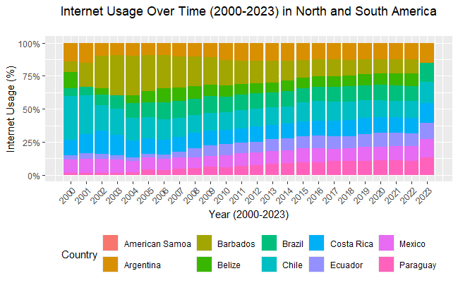

```r
library(scales)
#bar chart - showing top 10 north and south american countries with highest internet usage in 2000 to 2023

#calculating increase in internet usage
increase_usage <- data_sorted_united %>%
  mutate(change = `2023_clean`-`2000_clean`) %>% #compute change
  arrange(desc(change)) %>% #ordering countries by greatest increase
  slice_head(n=10) %>% #keeping top 10 results
  pull(`Country Name`) #extracting country name

#using stacked to handle missing data and show internet usage over years
data_long <- data_sorted_united %>% #converting data to long for easy plotting
  pivot_longer(cols = starts_with("20"),
               names_to ="Year",
               values_to = "Internet_Usage"
               ) %>%
  mutate(Year = as.integer(parse_number(Year))) #converting to column numeric

#handling missing values existing in some years by converting NA to 0 for displaying
data_long$Internet_Usage[is.na(data_long$Internet_Usage)] <- 0


#filtering for only the top 10 North or South american countries based on their 2023 usage
data_long_top_n_s_change <- data_long %>%
  filter(`Country Name` %in% increase_usage)

#normalizing internet usage percentage for better visualization
data_long_top_n_s_change <- data_long_top_n_s_change  %>%
  group_by(Year) %>%
  mutate(Internet_Usage = Internet_Usage/sum(Internet_Usage))


#creating the stacked bar chart
ggplot(data_long_top_n_s_change, aes(x=Year, y = Internet_Usage, fill = `Country Name`))+
  geom_bar(stat="identity", position="stack", na.rm=TRUE)+
  scale_x_continuous(breaks = seq(2000, 2023, 1))+
  scale_y_continuous(labels = label_percent()) +
  labs(title="Internet Usage Over Time (2000-2023) in North and South America", x="Year (2000-2023)", y="Internet Usage (%)", fill = "Country") +
  theme(
    legend.position = "bottom",
    plot.title = element_text(hjust = 0.5, margin = margin(b=20)), #centering title
    axis.text.x = element_text(angle = 45, hjust = 1) #rotating x axis for readability
  )
```

```r
NA
NA
```

#### Pie Chart

Here I continued to find an interest in Internet Data Usage except now I wanted to use more data. I created categories and defined them as High Usage over 66%, Medium between 33% to 66% and finally low as below 33%. Surpisingly the largerst group was medium usage. I tried finding syntax online to help figure out which Countries were in which categories of the pie chart, but it proved challenging. Instead I did an output of the countries that fell in the high usage category and the value was 2. Based on economy and the tecnical industry, it could be guessed those two countries were United States and Canada.

```r
#pie chart to show internet usage across countries (grouping them)

#calc avg internet usage over the years 2000  - 2023 to handle NA
data_sorted_united <- data_sorted_united %>%
  mutate(`Average Internet Usage`= rowMeans(select(., starts_with("20")), na.rm=TRUE)/100)

#creating usage groups by dividing per cent to 3 categories (Low, medium and high)
data_sorted_united <- data_sorted_united  %>%
  mutate(usage_group = case_when(
    is.na(`Average Internet Usage`) ~ "NA", #for NA values
    `Average Internet Usage` <= 0.33 ~ "Low Usage", #0% to #33%
    `Average Internet Usage` > 0.33 & `Average Internet Usage` <= 0.66 ~ "Medium Usage", #33% to #66%
    `Average Internet Usage` > 0.66 ~ "High Usage" #66% to #100%
  ))

#checking dist of usage groups
table(data_sorted_united$usage_group)
```

```
  High Usage    Low Usage Medium Usage           NA
           2            9           18            1
```

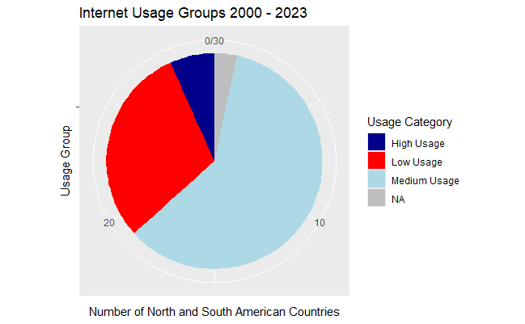

```r
#Counting number of countries in North and South per usage group
usage_counts <- data_sorted_united  %>%
  group_by(usage_group) %>%
  summarise(count = n())

#Create pie chart
ggplot(usage_counts, aes(x = "", y= count, fill=usage_group))+
  geom_bar(stat = "identity", width = 1)+
  coord_polar("y", start = 0)+
  labs(title = "Internet Usage Groups 2000 - 2023",
       x = "Usage Group",
       y = "Number of North and South American Countries",
       fill =  "Usage Category") +
  scale_fill_manual(values = c("Low Usage"="red", "Medium Usage" ="lightblue", "High Usage" = "darkblue", "NA" = "grey"))
```

```r
#troubleshooting
#print(data_sorted_united)
summary(data_sorted_united$`Average Internet Usage`)
```

```
   Min. 1st Qu.  Median    Mean 3rd Qu.    Max.    NA's
 0.1387  0.3031  0.3759  0.4029  0.4915  0.7986       1
```

#### Heat Map

I decided to use a heat map outputting 30 countries with their internet usage to show changes. As expected the higher usage was in recent years. This is an interesting result especially for Barbados because the stacked bar graph produced something different when understanding the results. However, this heat map used data for every year, so from this I determined it makes sense because technology has become more accessible and more frequently used than in earlier years (based on observation)

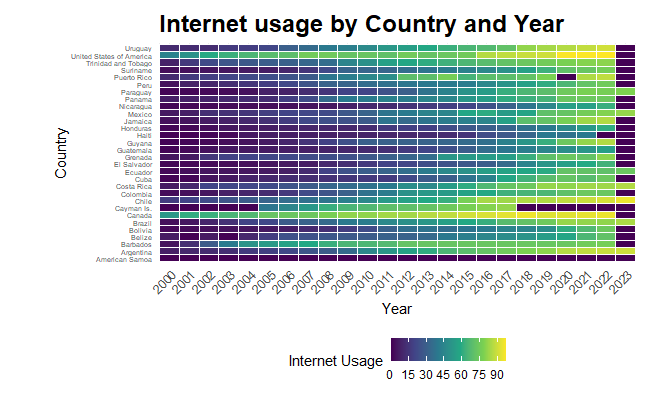

```r
#install.packages("viridis")
library(viridis)

#data_long$Internet_Usage[is.na(data_long$Internet_Usage)] <- 0
# Heatmap
ggplot(data_long, aes(x = Year, y = `Country Name`, fill = Internet_Usage)) +
geom_tile(color = "white") +
scale_fill_viridis_c(direction = 1,
                     breaks = seq(0, 100, by = 15)) +
scale_x_continuous(
  breaks = seq(2000, 2023, by = 1), #show all years
  expand = c(0,0) #remove extra space around x axis
)+

theme_minimal() +
theme(legend.position="bottom",
      plot.title = element_text(size = 18, face = "bold"),
      axis.text.x = element_text(angle = 45, hjust = 1), #rotate x axis labels
      axis.text.y = element_text(angle= 0, hjust=1, size = 5),
      plot.margin = margin(10,10,10,40) #making more space for y axis

    ) +

  labs(
    title = "Internet usage by Country and Year",
    x = "Year",
    y = "Country",
    fill = "Internet Usage"
)
```

```r
#trouble shooting
summary(data_long)
```

```
 Country Information Country Name        usage_2000
 Length:720          Length:720         Length:720
 Class :character    Class :character   Class :character
 Mode  :character    Mode  :character   Mode  :character



  usage_2023             Year      Internet_Usage
 Length:720         Min.   :2000   Min.   : 0.000
 Class :character   1st Qu.:2006   1st Qu.: 9.795
 Mode  :character   Median :2012   Median :33.695
                    Mean   :2012   Mean   :36.658
                    3rd Qu.:2017   3rd Qu.:61.495
                    Max.   :2023   Max.   :97.130
```

```r
sum(is.na(data_long$Internet_Usage))  # Check for missing values in Internet_Usage
```

```
[1] 0
```

```r
unique(data_long$`Country Name`)  # Check which countries are included
```

```
 [1] "Chile"                    "Argentina"
 [3] "Costa Rica"               "Brazil"
 [5] "Mexico"                   "Paraguay"
 [7] "Ecuador"                  "American Samoa"
 [9] "Barbados"                 "Belize"
[11] "Bolivia"                  "Canada"
[13] "Cayman Is."               "Colombia"
[15] "Cuba"                     "El Salvador"
[17] "Grenada"                  "Guatemala"
[19] "Guyana"                   "Haiti"
[21] "Honduras"                 "Jamaica"
[23] "Nicaragua"                "Panama"
[25] "Peru"                     "Puerto Rico"
[27] "Suriname"                 "Trinidad and Tobago"
[29] "United States of America" "Uruguay"
```

```r
print(unique(data_long$`Country Name`))  # List all countries present in the dataset
```

```
 [1] "Chile"                    "Argentina"
 [3] "Costa Rica"               "Brazil"
 [5] "Mexico"                   "Paraguay"
 [7] "Ecuador"                  "American Samoa"
 [9] "Barbados"                 "Belize"
[11] "Bolivia"                  "Canada"
[13] "Cayman Is."               "Colombia"
[15] "Cuba"                     "El Salvador"
[17] "Grenada"                  "Guatemala"
[19] "Guyana"                   "Haiti"
[21] "Honduras"                 "Jamaica"
[23] "Nicaragua"                "Panama"
[25] "Peru"                     "Puerto Rico"
[27] "Suriname"                 "Trinidad and Tobago"
[29] "United States of America" "Uruguay"
```